# Assignment: Lexicon-Based Sentiment Analysis with Bluesky Data

Aakriti Poudel

April 24, 2026

## Overview

In this lab we’ll collect posts from Bluesky Social using the `{atrrr}` package and apply lexicon-based sentiment analysis tools — the same tools we covered in lecture (VADER via `{vader}`, `{sentimentr}`, and `{tidytext}` lexicons). By the end you’ll have a working pipeline from API call to sentiment scores, and you’ll have a concrete sense of where these tools succeed and where they fall short. We’ll walk through some of this in class with sample data, then you’ll be responsible for completing it with your own data set for the assignment.

## Setup

### 1. Create a Bluesky account and app password (you’ll do this your assignment)

I created a Bluesky account at bsky.app. To get API access, I went to **Settings - Privacy and Security - App Passwords**, and created a new app password named “eds231-text-sentiment-analysis”, and copied the password it gave me.

I saved my credentials in `.Renviron` by running this in the console.

```r
# Run once in console (not in the Rmd)
usethis::edit_r_environ()
```

### 2.Packages

```r
# Install required packages
# install.packages(c("atrrr", "tidyverse", "tidytext", "sentimentr", "remotes", "devtools"))

# tidyvader isn't on CRAN:
# remotes::install_github("chris31415926535/tidyvader")
```

```r
# Load all necessary package
library(atrrr)
library(tidyverse)
library(tidytext)
library(sentimentr)
library(remotes)
library(tidyvader)
library(textdata)
```

## Part 1: Authenticate and Pull Posts

To connect to Bluesky, I authenticated using the credentials I stored in `.Renviron`. I only need to run this once per session.

```r
auth(
  user = Sys.getenv("BSKY_USER"),
  pass = Sys.getenv("BSKY_PASS")
)
```

We search for posts on an environmental keyword. We’ll use `"climate change"` as the default.

```r
# API call — only run this manually in the console
raw_posts <- search_post("climate change", limit = 1000)
```

```r
# Load data from CSV instead
raw_posts <- read.csv("https://raw.githubusercontent.com/MaRo406/EDS-231-text-sentiment/refs/heads/main/data/bluesky_climate_raw.csv")
```

Take a look at what came back:

```r
glimpse(raw_posts)
```

```
## Rows: 1,079
## Columns: 6
## $ uri          <chr> "at://did:plc:gd2ppw7t3oe4mht3kgf35gkr/app.bsky.feed.post…
## $ indexed_at   <chr> "2026-04-21 16:35:50.152", "2026-04-21 16:35:07.347", "20…
## $ text         <chr> "Chris Wright is a climate arsonist whose position can be…
## $ like_count   <int> 0, 0, 0, 2, 1, 0, 1, 0, 0, 0, 0, 1, 8, 24, 3, 6, 0, 205, …
## $ reply_count  <int> 0, 0, 0, 1, 0, 0, 0, 0, 0, 1, 0, 0, 0, 1, 0, 0, 1, 51, 0,…
## $ repost_count <int> 0, 0, 0, 1, 0, 0, 1, 0, 0, 0, 0, 1, 2, 2, 0, 0, 0, 60, 0,…
```

The key columns for our purposes are `text` (post content) and `uri` (unique identifier), and engagement metrics like `like_count` and `reply_count`.

## Part 2: Clean and Prepare Text

Pull out the columns we need and do basic cleaning.

```r
posts <- raw_posts %>%
  select(uri, indexed_at, text, like_count, reply_count, repost_count) %>%
  mutate(
    indexed_at = as.POSIXct(indexed_at), #who can tell me how to
    post_date  = as.Date(indexed_at),
    text_clean = str_remove_all(text, "https?\\S+"), #remove URLs
    text_clean = str_remove_all(text_clean, "@\\S+"),#remove mentions
    text_clean = str_replace_all(text_clean,"\u2019", "'"),
    text_clean = str_remove_all(text_clean, "'s\\b"),
    text_clean = str_squish(text_clean)) %>%
  filter(nchar(text_clean) > 10)
```

How many posts do we have?

```r
nrow(posts)
```

```
## [1] 1072
```

## Part 3: Word Frequency

Before running any sentiment analysis, look at what words are actually in the data and plot the most frequent.

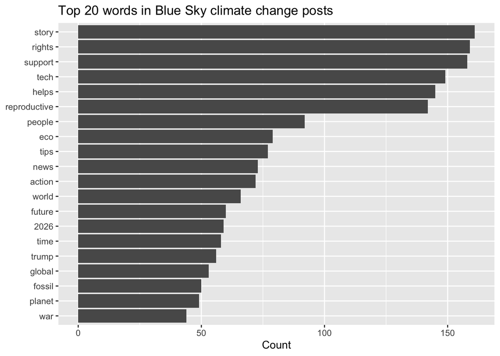

```r
# Pass 1: Standard stop words
data("stop_words")

tokens_clean <- posts %>%
  unnest_tokens(word, text_clean) %>%
  anti_join(stop_words, by = "word")

# Pass 2: Custom stop words and additional cleaning
custom_sw <- tibble(word = c(
  # search terms
  "climate", "change"
  # other common but uninformative text?
))

tokens_clean2 <- tokens_clean %>%
  anti_join(custom_sw, by = "word")

# Word frequency plot
word_counts <-tokens_clean2 %>%
  count(word, sort =TRUE)

word_counts %>%
  slice_max(n, n=20) %>%
  ggplot(aes(x=reorder(word, n), y=n)) +
           geom_col() +
           coord_flip() +
            labs(title = "Top 20 words in Blue Sky climate change posts",
                 x =NULL, y = "Count")
```

## Part 4: Sentiment Analysis

> **Note:** If you need to re-run any chunk in this section, run `rm(posts)` in the console first and re-run from Part 2. This avoids duplicate column errors.

### 4a. Bing lexicon (word-level)

Use `get_sentiments("bing")` to load the lexicon, then tokenize with `unnest_tokens()`, join to the lexicon with `inner_join()`, and compute a net score (positive word count minus negative word count) per post. Join the scores back onto `posts` with `left_join()`.

```r
bing <- get_sentiments("bing")

# Score posts with Bing
bing_scores <- posts %>%
  unnest_tokens(word, text_clean) %>%
  inner_join(bing, by = "word") %>%
  count(uri, sentiment) %>%
  pivot_wider(names_from = sentiment, values_from = n, values_fill = 0) %>%
  mutate( bing_score = positive - negative)

# Join scores to posts
posts <- posts %>%
  left_join(bing_scores, "uri") %>%
  mutate(bing_score = replace_na(bing_score, 0 ))
```

### 4b. AFINN lexicon (numeric scores)

Load with `get_sentiments("afinn")`. Unlike Bing, each matched word carries an integer value (−5 to +5), so summarize by summing those values within each post using `group_by()` and `summarise()`.

```r
# You will be prompted to download the AFINN lexicon the first time —
# run this line in the console and select Yes, then it will be cached locally
afinn <- get_sentiments("afinn")

# Score text (break each post into words, match to afinn, sum the scores per post)
afinn_scores <- posts %>%
  unnest_tokens(word, text_clean) %>%
  inner_join(afinn, by = "word") %>%
  group_by(uri) %>%
  summarise(afinn_score = sum(value))

# Join scores to posts, fill missing with 0 (posts with no matched words)
posts <- posts %>%
  left_join(afinn_scores, by = "uri") %>%
  mutate(afinn_score = replace_na(afinn_score, 0))
```

### 4c. NRC lexicon (emotion categories)

The NRC lexicon tags words with 8 emotions (anger, fear, anticipation, trust, surprise, sadness, joy, disgust) plus positive/negative. Now count emotion words per post and visualize which emotions dominate the corpus.

```r
nrc <- get_sentiments("nrc")

# Break posts into words and match to NRC emotion categories
nrc_scores <- posts %>%
  unnest_tokens(word, text_clean) %>%
  inner_join(nrc, by = "word", relationship = "many-to-many") %>%
  filter(!sentiment %in% c("positive", "negative"))

# Count how many emotion words each post has (one row per post per emotion)
nrc_post_scores <- nrc_scores %>%
  count(uri, sentiment)

# Join back to posts (wide format, one column per emotion)
posts <- posts %>%
  left_join(nrc_post_scores %>%
              pivot_wider(names_from = sentiment, values_from = n, values_fill = 0,
                          names_prefix = "nrc_"), by = "uri")
```

Which emotions dominate the corpus? Plot the count of total scored words for each of the 8 emotions.

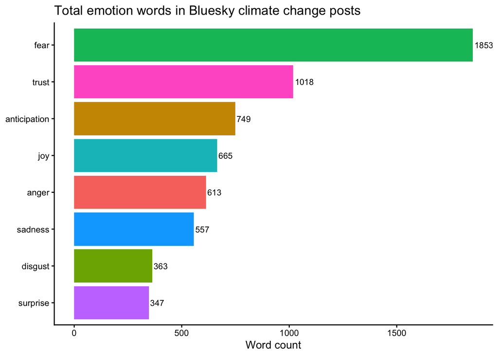

```r
# Count total words in each emotion category across all posts
nrc_scores %>%
  count(sentiment) %>%
  ggplot(aes(x = reorder(sentiment, n), y = n, fill = sentiment)) +
  geom_col(show.legend = FALSE) +
  geom_text(aes(label = n), hjust = -0.1, size = 3) +
  coord_flip() +
  labs(title = "Total emotion words in Bluesky climate change posts",
       x = NULL,
       y = "Word count") +
  theme_classic()
```

What words are driving each emotion? Create plots of the top 10 words for each emotion (hint: ggplot and `facet_wrap(~sentiment)`).

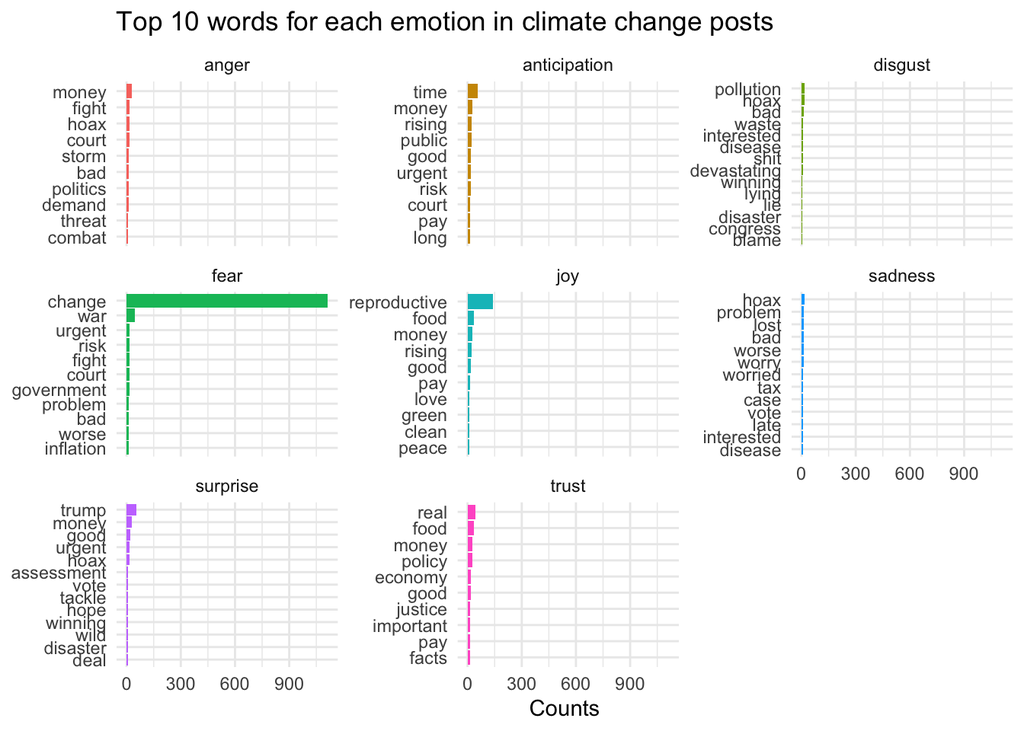

```r
# Find the top 10 words driving each emotion
posts %>%
  unnest_tokens(word, text_clean) %>%
  inner_join(nrc, by = "word", relationship = "many-to-many") %>%
  filter(!sentiment %in% c("positive", "negative")) %>%
  count(sentiment, word, sort = TRUE) %>%
  group_by(sentiment) %>%
  slice_max(n, n = 10) %>%
  ungroup() %>%
  ggplot(aes(x = reorder_within(word, n, sentiment), y = n, fill = sentiment)) +
  geom_col(show.legend = FALSE) +
  scale_x_reordered() +
  coord_flip() +
  facet_wrap(~sentiment, scales = "free_y") +
  labs(
    title = "Top 10 words for each emotion in climate change posts",
    x = NULL,
    y = "Counts") +
  theme_minimal()
```

### 4d. sentimentr (sentence-aware)

Unlike the word-level lexicons above, `{sentimentr}` scores at the sentence level and handles valence shifters like negation — “not alarming” won’t score the same as “alarming.” Pass the full `text_clean` vector to `sentiment_by()`. Rename the resulting `ave_sentiment` to `sr_scores` and join back onto `posts` by row index. I’ll give you this code as we haven’t fully covered this yet.

```r
# Split text into sentences first, then score each post
sr_scores <- sentiment_by(get_sentences(posts$text_clean)) %>%
  select(element_id, ave_sentiment) %>%
  rename(sr_score = ave_sentiment) %>%
  mutate(element_id = as.integer(element_id))

# Join scores back to posts by row index
posts <- posts %>%
  mutate(element_id = row_number()) %>%
  left_join(sr_scores, by = "element_id")
```

### 4e. VADER

VADER scores the full post text (no tokenization needed) and returns four values: `pos`, `neu`, `neg`, and `compound`. Use `tidyvader::vader()` on the `text_clean` column — it mutates the result directly onto the dataframe. Keep only the `compound` score and drop the component columns.

Let’s run VADER on a single post manually before applying it to the whole dataset:

```r
# Look at a few posts
posts %>% select(text_clean) %>% slice(1:10)
```

```
##                                                                                                                                                                                                                                                                                                     text_…
## 1                                                                                                                               Chris Wright is a climate arsonist whose position can be summarized by saying, yeah, climate change is happening and it totally worth it. coloradonewsline.com/2025/03/27…
## 2                    Trump, Maga and the GOP all claim that there no climate change and everything is peachy… I wonder if we can hold them all legally accountable for neglect, dereliction of duty and being stupid. Strict water use rules sweep the nation ahead of summer www.usatoday.com/story/news…
## 3           The consensus among exoerts is that the jet stream is slower, more prone to stalling, & shifting poleward on average — with real consequences for extreme weather. There some debate about whether that "waviness" is due to climate change, but from what I've read, most scientists think i…
## 4                                                        I heard a bit on NPR about Fed chair nominee Kevin Warsh and how he doesn't want the Fed to "Get into political issues, such as climate change" And I just want to hit my head against the desk CLIMATE CHANGE IS NOT A POLITICAL ISSUE. IT IS A…
## 5           The consensus among exoerts is that the jet stream is slower, more prone to stalling, & shifting poleward on average — with real consequences for extreme weather. There some debate about whether that "waviness" is due to climate change, but from what I've read, most scientists think i…
## 6                                                                                                                                                                                                      They understand jet stream changes... but it couldn't POSSIBLY be changing because of CLIMATE CHAN…
## 7                                                  Wright is just blatantly lying. While some periods show relative stability, long-term data indicates a significant downward trend, with snowpack in parts of the Colorado River Basin decreasing by roughly 41% between 1982 and 2016 due to climate c…
## 8                                                                                                                                          Netanyahu would be arrested if he came to Hungary, says new PM Your support helps us to tell the story From reproductive rights to climate change to Big Tech,…
## 9                             yep, I said it too. Climate change ( loss if water and arable land) will force millions to migrate to urban centers not equipped to deal with the population overload,collapsing infrastructure. Think of tribal warfare coming Haves vs the have nots. Heck we're already …
## 10 i, on the other hand, my natural inclination would be to only start a talk with "wow, the weather, huh?" if i wanted to talk about, say, climate change and didn't know a more substantive onramp into the issue for the individual i am speaking to. again, i am gathering that this is atypical for …
```

```r
# Run VADER on one post, swap in whichever row looks interesting to you
posts$text_clean[3]
```

```
## [1] "The consensus among exoerts is that the jet stream is slower, more prone to stalling, & shifting poleward on average — with real consequences for extreme weather. There some debate about whether that \"waviness\" is due to climate change, but from what I've read, most scientists think it is.…
```

```r
tidyvader::vader_chr(posts$text_clean[3])
```

```
##   compound pos    neu    neg
## 1   -0.136   0 0.9691 0.0309
```

What did VADER catch? What did it miss? How does the compound score relate to the word-level scores?

## Now score all the posts with VADER. Rename it’s default scoring column to `vader_score`.

```r
# Run VADER on each post and keep only the compound score
posts <- posts %>%
  select(-any_of(c("vader_score", "pos", "neu", "neg"))) %>%  # drop if already exists from a previous run
  tidyvader::vader(text_clean) %>%
  rename(vader_score = compound) %>%
  select(-pos, -neu, -neg)
```

## Part 5: Compare the Methods

### Correlations

Let’s see to what extent the 4 numerical methods (bing, afinn, sr, and vader) are in agreement. Select the 4 scores and use `cor()` using “complete.obs”.

```r
# Check how much the four methods agree with each other
posts %>%
  select(any_of(c("bing_score", "afinn_score", "sr_score", "vader_score"))) %>%
  cor(use = "complete.obs") %>%
  round(2)
```

```
##             bing_score afinn_score sr_score vader_score
## bing_score        1.00        0.71     0.59        0.63
## afinn_score       0.71        1.00     0.64        0.80
## sr_score          0.59        0.64     1.00        0.62
## vader_score       0.63        0.80     0.62        1.00
```

### Score distributions

Use `pivot_longer()` to reshape the four score columns into a single `score` column with a `method` identifier, then plot with `geom_histogram()` and `facet_wrap()`.

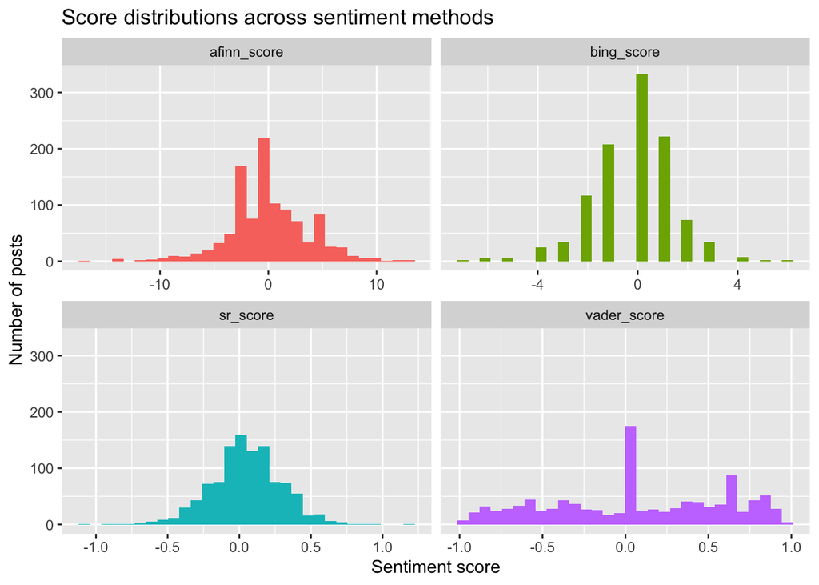

```r
# Reshape scores from wide to long so each method gets its own panel
posts %>%
  select(uri, bing_score, afinn_score, sr_score, vader_score) %>%
  pivot_longer(
    cols = c(bing_score, afinn_score, sr_score, vader_score),
    names_to  = "method",
    values_to = "score") %>%
  ggplot(aes(x = score, fill = method)) +
  geom_histogram(bins = 30, show.legend = FALSE) +
  facet_wrap(~method, scales = "free_x") +  # free x so each method uses its own scale
  labs(title = "Score distributions across sentiment methods",
       x = "Sentiment score",
       y = "Number of posts")
```

**Question 1:** Do the four methods broadly agree or disagree? Where do you see the biggest differences in the distributions? Which method produces the most zeros, and why?

`AFINN` spreads out the most, with scores ranging from about -10 to +10. This is because it adds up word scores across the whole post, so longer posts with more emotional words get bigger totals. `Bing` is similar but more compressed. It only counts positive vs. negative words without weighting them.

`Bing` produces the most zeros. When a post has no words that match the Bing list at all, which happens often with political or scientific language, the score comes out as zero by default. The tall bar at zero in the `Bing` panel shows this clearly.

## Part 6: Spot-Check for Misclassification

Find posts where the methods disagree most — these are the best candidates for understanding failure modes. Use `mutate()` to create binary flags from the continuous scores, then `filter()` for posts where the two methods point in opposite directions.

```r
# Find posts where VADER and Bing point in opposite directions
posts %>%
  mutate(vader_pos = vader_score > 0,  # TRUE if VADER says positive
         bing_pos  = bing_score  > 0   # TRUE if Bing says positive
         ) %>%
  filter(vader_pos != bing_pos) %>%  # keep only posts where they disagree
  select(text_clean, bing_score, vader_score) %>%
  slice_head(n = 10)
```

```
##                                                                                                                                                                                                                                                                                                     text_…
## 1                                                        I heard a bit on NPR about Fed chair nominee Kevin Warsh and how he doesn't want the Fed to "Get into political issues, such as climate change" And I just want to hit my head against the desk CLIMATE CHANGE IS NOT A POLITICAL ISSUE. IT IS A…
## 2                                                                                              Nato fighter jets scrambled to intercept Russian military aircraft flying over Baltic Sea Your support helps us to tell the story From reproductive rights to climate change to Big Tech, The…#uk #news #u…
## 3                                                                                                                Okay, Chris, so why did the path of the jet stream shift last year? Could it be due to fluctuations in the polar vortex caused by shrinking polar ice caps, in turn caused by climate ch…
## 4                                                                                Eco- and climate- friendly solutions can help deal with this increasing pest pressure. Here how climate change affects our agriculture ➡️ lnkd.in/eTh78v4a #pestcontrol #pestpressure #climatechange #agpests #climatefr…
## 5                                                                                                                                                                                                                                                                      Lead the world in what? Climate ch…
## 6                                                                                                                                                                                             I expect climate change will result in above normal summer temps... i'd rather this chilly weather to be ho…
## 7  "... scientists must explain complex environmental realities to... people whose livelihoods, identities, cultures, and futures are tied to forests. Climate change, invasive species, and land exploitation all coincide with... approaches that have deeply social, political, and economic implicati…
## 8      It not everyday you change a life! Over 2 billion underbanked people worldwide are a single major climate event away from losing everything. Learn more about how Kiva is supporting the communities most at risk - and how your action today plays a role. www.kiva.org?utm_source=b... #charity …
## 9                                                                     I feel your frustration! It disheartening when powerful voices dismiss climate action as impossible or partisan. We need people like you who care deeply about the future, not just the present. Let keep pushing for change togeth…
## 10   Organic crops can feed global human pop, replace Animal Ag wh uses 50% of lands & waters of Earth while poluting all elements, disupting Natural Balances that give life to all forms. Climate change causes also include the deforestation committed by Animal Ag. www.sciencedirect.com/science/ar…
##    bing_score vader_score
## 1          -2      0.0201
## 2           0      0.7096
## 3           0      0.3094
## 4           0      0.6597
## 5           1      0.0000
## 6           0      0.5562
## 7          -3      0.2263
## 8          -1      0.4613
## 9          -2      0.4389
## 10          0      0.5574
```

To rank posts by total disagreement, compute the absolute difference between the two scores with `abs()`, then `arrange(desc(...))` to surface the highest-conflict posts.

```r
# Rank posts by how much VADER and Bing disagree
posts %>%
  mutate(
    # Normalize bing to [-1, 1] so it's on the same scale as vader, then take the difference
    conflict = abs(vader_score - (bing_score / max(abs(bing_score), na.rm = TRUE)))) %>%
  arrange(desc(conflict)) %>%        # put the biggest disagreements at the top
  select(text_clean, bing_score, afinn_score, sr_score, vader_score) %>%
  slice_head(n = 10)                 # show the 10 most conflicted posts
```

```
##                                                                                                                                                                                                                                                                                                      text…
## 1                                            Do you think the frozen conflict could stall climate change? Perhaps it could act as a third pole. We've lost the Arctic, but hell is freezing over on the Middle East. Hurrah, we are saved. I always knew that nice Mr Trump would save the day. Morning D…
## 2                                          🧬🌱 New paper in Heredity We revisit the role of marginal populations and show they are not evolutionary dead ends. Using a genomic framework, we highlight their importance for long-term persistence and adaptation under climate change. doi.org/10.1038/s41…
## 3                                                   Climate change isn't real (sarcasm making sure that obvious lol) Now please excuse me while I pay higher insurance premiums because of frequent 'one in a hundred year weather events' that is, if the insurance company hasn't blacklisted my area c…
## 4                              “If you care about human health or antimicrobial resistance, risk of pandemic disease, plastic pollution, deforestation, loss of biodiversity, climate change, gas emissions, land use change...it is all an issue of justice and rights..." www.theguardian.com/global/20…
## 5                                                   yeah except the renewables industry is pushing the idea that we NEED this huge data center demand because it will create a revolution in solar demand and then step 3 ??????? and then step 4 invisible hand of the market solves climate change \U{0…
## 6                                                     Do you not acknowledge that if Ralph Nader not run a campaign he KNEW he couldn't win, he gave the election to Bush who took us to war in Iraq and promulgated anti climate change policies for energy companies?? I find it to be factual. Facts m…
## 7                                                                                               Unusual gardening hacks to save time and money Your support helps us to tell the story From reproductive rights to climate change to Big Tech, The Independent is on the ground when the story is develop…
## 8  So I realize most of you follow me for my moral outrage even though I only made this profile as a writer. Occasionally, the moral outrage had to come through though. But I promise, its all in the book: Bloodied Constellations. Protecting the innocent, climate change, social justice, animal rig…
## 9                                                Online TOMORROW at 5:30 pm PT! Learn how filmmaking can tackle climate change with filmmaker Daniel Goldhaber (‘How to Blow Up a Pipeline') & producer Sarah Eagle Heart (‘Lakota Nation vs. United States & Crow: The Legend'). Register here: bit.ly/4…
## 10              Honestly, every lobby is getting this world destroyed! Their lust for money and power is hurting humaniy as a whole! The fossil industrie blocks every move to reverse climate change, the gun industry is ok with exploding gun violence and the war industry is very happy with the Ira…
##    bing_score afinn_score    sr_score vader_score
## 1          -4           1 -0.20944505      0.7845
## 2          -2           1  0.24182604      0.8096
## 3          -2           2  0.14844316      0.7885
## 4          -4          -1 -0.10248358      0.4939
## 5          -1           1 -0.06264782      0.8708
## 6           1           1 -0.01320843     -0.8192
## 7          -1           7  0.18644283      0.8176
## 8          -1          -3  0.22710509      0.8167
## 9          -1           1  0.09519829      0.8070
## 10          0         -14 -0.28177946     -0.9440
```

**Question 2:** Read through 5 of the high-conflict posts. For each one, write a sentence explaining which method you think is closer to correct and why.

**Question 3:** Based on everything you’ve run, which method would you choose if you were delivering a report on public sentiment around your topic, and why? What additional steps would you take to validate your choice?

**Answer:** I would use `VADER`. Climate change posts on Bluesky are short and emotional, and `VADER` was built for that kind of text. It also scored every post, not just ones with matched words like Bing does. The correlation table backs this up. `VADER` and `AFINN` agreed the most (0.80), which suggests `VADER` is tracking real sentiment.

To validate, I would hand label around 100 posts myself and see how often `VADER` agrees. I would also read through the posts where `VADER` and `sentimentr` disagree most to see which one got it right.

## Bonus: Engagement vs. Sentiment (completion optional)

Do more emotionally charged posts get more engagement? Use `abs()` on the VADER compound score to capture emotional intensity regardless of direction, apply `log1p()` to `like_count` to handle the skewed distribution, and add `geom_smooth(method = "lm")` to visualize the trend.

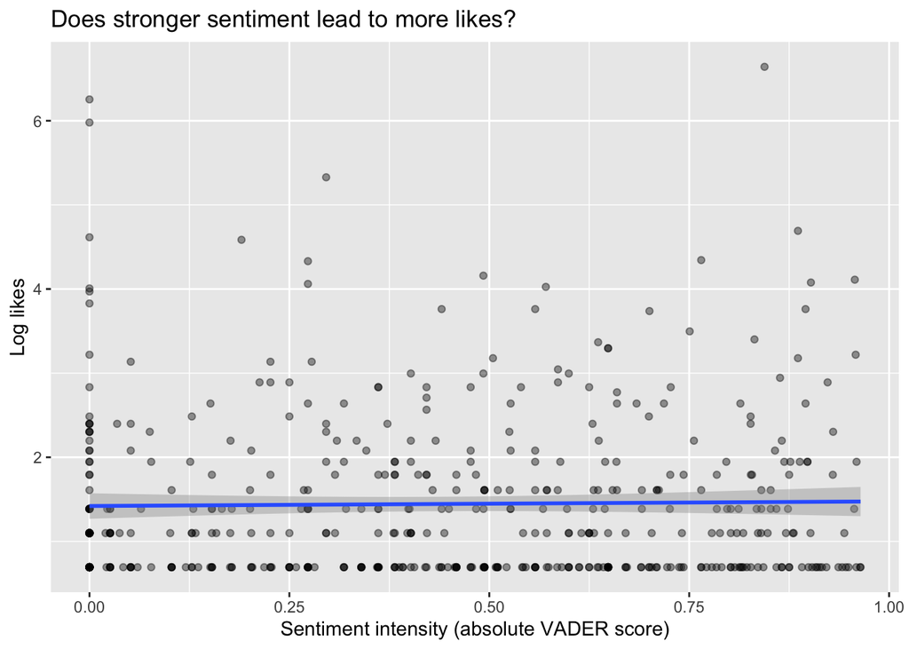

```r
# Do more emotional posts get more likes?
posts %>%
  filter(like_count > 0) %>% # remove posts with no likes
  mutate(
    sentiment_intensity = abs(vader_score), # intensity regardless of positive or negative
    log_likes = log1p(like_count) # log scale to handle posts with very high likes
  ) %>%
  ggplot(aes(x = sentiment_intensity, y = log_likes)) +
  geom_point(alpha = 0.4) +
  geom_smooth(method = "lm", formula = y ~ x) +
  labs(title = "Does stronger sentiment lead to more likes?",
       x = "Sentiment intensity (absolute VADER score)",
       y = "Log likes")
```

**Bonus:** Is there a relationship between sentiment intensity and engagement? What does that suggest about what gets amplified on Bluesky?

**Answer:**

The trend line is nearly flat, so there is no clear relationship between sentiment intensity and likes. Emotional posts do not consistently get more likes than neutral ones on Bluesky.

This suggests that on Bluesky, what gets attention is not just how emotional a post is. Other things like who posted it, how many followers they have, or whether it was reposted likely matter more than sentiment alone.